# Taller 1 - Análisis Avanzado de Datos

*Estudiante 1: Felipe Sarmiento Henriquez*

*Estudiante 2: Juan Sebastian Henao Parra*

*31 de marzo de 2023*

**Problema.** El conjunto de datos taller1.txt contiene la información del perfíl genómico de un conjunto de 1200 líneas celulares. Para estas se busca determinar cúales de los 5000 genes (ubicados en cada columna) son de relevancia para la predicción de la variable respuesta (efectividad del tratamiento anticancer, medida como variable continua). Responda las siguientes preguntas:

1. **¿Hay multicolinealidad en los datos? Explique sucintamente.**

En entornos de alta dimensiónalidad, en los que el número de variables predictoras (p) supera al de observaciones (n), los métodos estadísticos tradicionales suelen encontrar dificultades para producir resultados fiables. Este escenario de “*large p, small n*” los analisis presentan retos que pueden tener implicaciones en la estabilidad e interpretabilidad de los modelos .

La multicolinealidad es una preocupación habitual en este contexto, ya que una elevada multicolinealidad puede dar lugar a estimaciones inestables de los coeficientes en los modelos de regresión, errores estándar inflados y dificultades para determinar la contribución individual de cada predictor a la variable de respuesta.

Abordar la multicolinealidad en datos genómicos de alta dimensión como el propuesto en este taller requiere técnicas y estrategias especializadas. A continuación se describen algunos enfoques posibles:

- **Reducción de la dimensionalidad:** Las técnicas de reducción de la dimensionalidad tienen como objetivo proyectar datos de alta dimensión en un espacio de menor dimensión, preservando al mismo tiempo la estructura y las relaciones esenciales dentro de los datos. El análisis de componentes principales (PCA) es una técnica ampliamente utilizada que identifica combinaciones lineales ortogonales de variables originales denominadas componentes principales que capturan la máxima varianza en los datos. La regresión por mínimos cuadrados parciales (PLS) es otro método que, al igual que el PCA, proyecta tanto las variables predictoras como las variables de respuesta en un espacio de dimensiones inferiores, pero con el objetivo añadido de maximizar la covarianza entre las variables predictoras proyectadas y la variable de respuesta.
- **Selección de características:** Los métodos de selección de características buscan identificar un subconjunto de predictores relevantes y descartar los irrelevantes o redundantes. Para los datos de alta dimensión se han desarrollado técnicas de regresión dispersa como LASSO (Least Absolute Shrinkage and Selection Operator) y Elastic Net . LASSO es un método lineal que realiza tanto la selección de variables como la regularización reduciendo algunos coeficientes a cero”.

En este taller utilizaremos el enfoque de selección de caracteristicas. Más alla de abordar el problema de la colinealidad en nuestro conjunto de datos, que se da por supuesta dadas las dimensiones del conjunto de datos, realizaremos una corta exploración de los datos, calcularemos las estadísticas de resumen de las variables para comprender la tendencia central, la dispersión y la distribución de los datos.

```r
#install.packages("ggplot2")
#install.packages("reshape2")
#install.packages("gridExtra")
#install.packages("tidyr")
#install.packages("ggdraw")
#install.packages("wesanderson")
#install.packages("car")
#install.packages("corrplot")
#install.packages("caret")
#install.packages("reshape2")
#install.packages("ggthemes")
#install.packages("gridExtra")
#install.packages("tidyverse")
#install.packages("glmnet")


# Load required libraries
library(ggplot2)
library(dplyr)
library(tidyr)
library(dplyr)
library(wesanderson)
library(car)
library(corrplot)
library(caret)
library(reshape2)
library(ggthemes)
library(gridExtra)
library(tidyverse)
library(gplots)
library(glmnet)
```

```r
# Cargar los datos del archivo txt
data <- read.table("C:\\Users\\felip\\Downloads\\Taller 1  - AAD\\taller1.txt", header = TRUE, sep = ",")
```

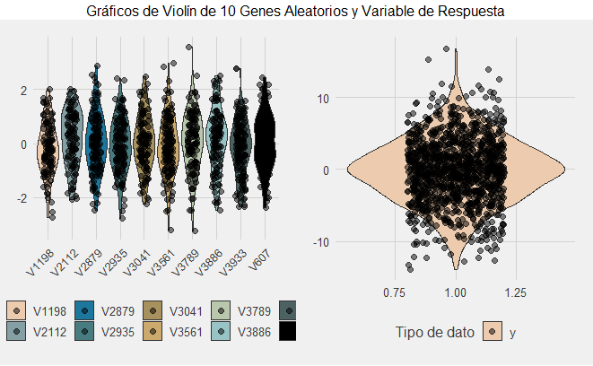

```r
# Seleccionar 10 genes aleatorios del conjunto de datos
genes_seleccionados <- sample(colnames(data)[-ncol(data)], 10)

# Crear un nuevo dataframe con los 10 genes seleccionados y la variable de respuesta 'y'
datos_sub <- data[, c(genes_seleccionados, "y")]

# Reorganizar el conjunto de datos para graficar
datos_grafico <- data.frame(Gene = factor(rep(genes_seleccionados, each = nrow(datos_sub))),
                            Valor = as.vector(as.matrix(datos_sub[, genes_seleccionados])),
                            TipoDato = "Gen")

# Reducir la cantidad de puntos en el gráfico
tasa_muestreo <- 0.1
datos_grafico_muestreado <- datos_grafico[sample(1:nrow(datos_grafico), nrow(datos_grafico) * tasa_muestreo), ]

# Crear un gráfico de violín para los genes seleccionados
genes_grafico <- ggplot(datos_grafico_muestreado, aes(x = Gene, y = Valor, fill = Gene)) +
  geom_violin(scale = "width") +
  geom_jitter(width = 0.2, size = 2, alpha = 0.5) +
  theme_fivethirtyeight() +
  scale_fill_manual(values = wes_palette("Darjeeling2", n = 10, type = "continuous"), name = "Gen") +
  labs(x = "Genes", y = "Valor") +
  theme(axis.text.x = element_text(angle = 45, hjust = 1))



# Crear un gráfico de violín para la variable de respuesta 'y'
y_grafico <- ggplot(datos_sub, aes(x = 1, y = y, fill = "y")) +
  geom_violin(scale = "width") +
  geom_jitter(width = 0.2, size = 2, alpha = 0.5) +
  theme_fivethirtyeight() +
  scale_fill_manual(values =  wes_palette("Darjeeling2"), name = "Tipo de dato", labels = "y") +
  labs(x = "y", y = "Valor")

# Agregar título a los gráficos
grid.arrange(genes_grafico, y_grafico, ncol = 2, top = "Gráficos de Violín de 10 Genes Aleatorios y Variable de Respuesta")
```

2. **Separe aleatoriamente (pero guarde la semilla) su conjunto de datos en dos partes:**

```r
# establecer semilla para reproducibilidad
set.seed(42)
# definir el tamaño de los conjuntos de entrenamiento y test
train_size = 1000/1205
sample <- sample(c(TRUE, FALSE), nrow(data), replace=TRUE, prob=c(train_size, 1-train_size))
# crear los conjuntos de train y test
train  <- data[sample, ]
test   <- data[!sample, ]

# Definir la variable de respuesta objetivo en train y test
y_train <- train$y
y_test <- test$y

# Definir las covariables en train y test
x_train <- train[,-1]
x_test <- test[,-1]
```

3. **Usando los 1000 datos de entrenamiento, determine los valores de λr y λl de regesión ridge y lasso, respectivamente, que minimicen el error cuadrático medio (ECM) mediante validación externa. Utilice el método de validación externa que considere más apropiado**

   La validación cruzada usando 10-fold es un enfoque adecuado para la validación externa debido a:
   - Estabilidad: Al promediar los resultados de 10 pliegues, se obtiene una estimación más estable del rendimiento del modelo.
   - Mitigación del sobreajuste: Provee una evaluación más realista del rendimiento en datos no vistos, reduciendo el riesgo de sobreajuste.
   - Equilibrio entre sesgo y varianza: La elección de 10 pliegues representa un compromiso adecuado entre sesgo y varianza en la estimación del rendimiento del modelo.

```r
#Correr el modelo
fit_ridge <- cv.glmnet(x=as.matrix(x_train), y=unlist(y_train), type.measure="mse", alpha=0, nlambda=200)
```

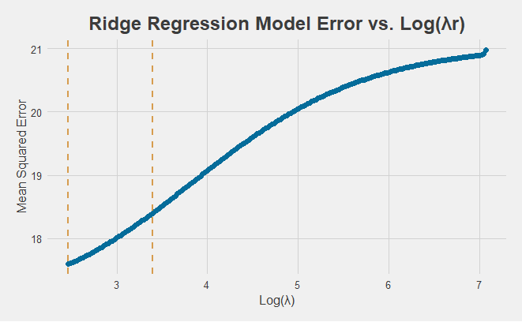

```r
# Determine the optimal lambda value
optimal_lambda <- fit_ridge$lambda.min

# Extraer los valores de error y lambda del modelo
lambda_values <- fit_ridge$lambda
error_values <- fit_ridge$cvm
#color lineas verticales
color_v = wes_palette("Darjeeling2")[3]
# Create the ggplot object with the specified theme and color scheme
ridge_plot <- ggplot(ridge_data, aes(x = log(lambda), y = error)) +
  geom_line(color = wes_palette("Darjeeling2")[1], size = 1) +
  geom_point(color = wes_palette("Darjeeling2")[2], size = 2)  +
  geom_vline(aes(xintercept = log(optimal_lambda)), linetype = "dashed", color = color_v, size = 1)+
  geom_vline(aes(xintercept = log(fit_ridge$lambda.1se)), linetype = "dashed", color = color_v, size = 1)+
  theme_fivethirtyeight() +
  labs(title = "Ridge Regression Model Error vs. Log(λr)",
       x = "Log(λ)",
       y = "Mean Squared Error") +
  theme(plot.title = element_text(hjust = 0.5),
        axis.title.x = element_text(size = 12),
        axis.title.y = element_text(size = 12))
# Display the plot
print(ridge_plot)
```

```r
fit_ridge$lambda.min
```

```
[1] 11.76828
```

El valor óptimo de λr con regresión Ridge es **11.76828**

Ahora al realizar el análsis con regressión Lasso:

```r
fit_lasso <- cv.glmnet(x=as.matrix(x_train), y=unlist(y_train), type.measure="mse", alpha=1, nlambda=200, nfolds=10)
```

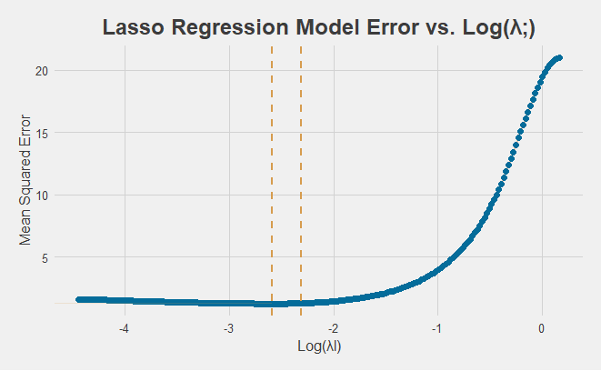

```r
# Extraer los valores de lambda y error del modelo
lambda_values <- fit_lasso$lambda
error_values <- fit_lasso$cvm

# Crear un marco de datos con los valores extraídos
lasso_data <- data.frame(lambda = lambda_values, error = error_values)

# Determinar el valor de lambda optimo
optimal_lambda <- fit_lasso$lambda.min

# Calcular el MSE como un umbral
mse_min <- min(error_values)
mse_threshold <- mse_min + fit_lasso$cvsd[which.min(error_values)]

# Crear la grafica
lasso_plot <- ggplot(lasso_data, aes(x = log(lambda), y = error)) +
  geom_line(color = wes_palette("Darjeeling2")[1], size = 1) +
  geom_point(color = wes_palette("Darjeeling2")[2], size = 2) +
  geom_vline(aes(xintercept = log(optimal_lambda)), linetype = "dashed", color = color_v, size = 1) +
  geom_vline(aes(xintercept = log(fit_lasso$lambda.1se)), linetype = "dashed", color = color_v, size = 1) +
  annotate("rect", xmin = -Inf, xmax = log(optimal_lambda), ymin = mse_min, ymax = mse_threshold, alpha = 0.2, fill = color_v) +
  theme_fivethirtyeight() +
  labs(title = "Lasso Regression Model Error vs. Log(λ;)",
       x = "Log(λl)",
       y = "Mean Squared Error") +
  theme(plot.title = element_text(hjust = 0.5),
        axis.title.x = element_text(size = 12),
        axis.title.y = element_text(size = 12))

# Display
print(lasso_plot)
```

```r
fit_lasso$lambda.min
```

```
[1] 0.07494334
```

4. **Ajuste la regresión ridge y lasso con los valores estimados de λr y λl obtenidos en (3) usando los 1000 datos de entrenamiento.**

```r
# Ajustar el modelo de regresión Ridge utilizando los datos de entrenamiento y el valor óptimo de lambda (lambda.min) obtenido del modelo fit_ridge
best_ridge <- glmnet(as.matrix(x_train), unlist(y_train), alpha=0, lambda=fit_ridge$lambda.min)

# Ajustar el modelo de regresión Lasso utilizando los datos de entrenamiento y el valor óptimo de lambda (lambda.min) obtenido del modelo fit_lasso
best_lasso <- glmnet(as.matrix(x_train), unlist(y_train), alpha=1, lambda=fit_lasso$lambda.min)
```

5. **Para los modelos ajustados en (4) determine el más apropiado para propósitos de predicción. Considere únicamente el ECM en los 200 datos de prueba para su decisión.**

```r
best_ridge_pred<- predict(best_ridge, newx= as.matrix(x_test))
ridge_mse <- mean((unlist(y_test) - best_ridge_pred)^2)
best_lasso_pred <- predict(best_lasso, newx= as.matrix(x_test))
lasso_mse <- mean((unlist(y_test) - best_lasso_pred)^2)

cat("ECM Ridge:", ridge_mse, "\n")
```

```
ECM Ridge: 15.19369
```

```r
cat("ECM Lasso:", lasso_mse, "\n")
```

```
ECM Lasso: 1.057821
```

6. **Ajuste el modelo seleccionado en (5) para los 1200 datos. Note que en este punto ya tiene un λ estimado y un modelo seleccionado.**

```r
# Definir la variable objetivo
y <- data$y

# Definir la matriz de variables predictoras
x <- data[,-1]

complete_model <- glmnet(x, y, alpha = 1, lambda = fit_lasso$lambda.min)
```

Se crea el objeto ‘complete_model’ que contiene el modelo Lasso ajustado con el valor óptimo de λl previamente estimado utilizando los 1.200 datos del conjunto completo. Este modelo puede utilizarse para realizar predicciones en nuevos datos.

7. **Grafique las trazas de los coeficientes en función de la penalización para el modelo ajustado en (6).**

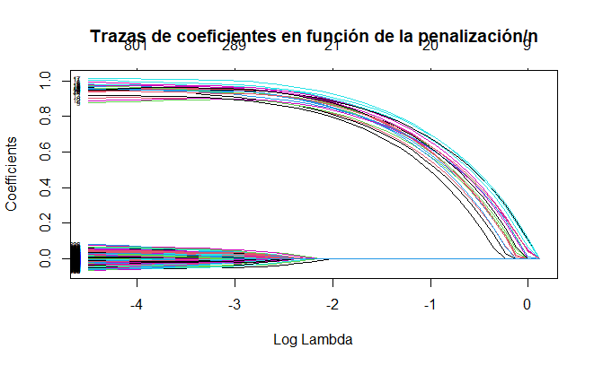

```r
lasso_model_range <- glmnet(as.matrix(x), unlist(y), alpha = 1, nlambda = 40)

# Gráfico
plot(lasso_model_range, xvar = "lambda", label = TRUE)
title("Trazas de coeficientes en función de la penalización/n")
```

8. **En un párrafo resuma los resultados obtenidos dado el objetivo inicial del estudio.**

Al analizar un conjunto de datos genómicos con 5,000 variables que representan información de genes, el objetivo era determinar qué variables son más relevantes para la variable de respuesta. Para abordar este problema, se ajustaron modelos de regresión Lasso y Ridge, encontrando valores óptimos de lambda para cada modelo.

Después, se ajustó el modelo Lasso óptimo a todo el conjunto de datos y se trazaron los coeficientes en función de la penalización (log(lambda)). El trazado de las trazas de coeficientes permite visualizar cómo cambian los coeficientes en función de la penalización aplicada. En el modelo Lasso, a medida que aumenta la penalización, algunos coeficientes se vuelven exactamente cero, lo que indica que estas variables no son relevantes para predecir la variable de respuesta.

A partir de los resultados obtenidos en este análisis, se puede concluir que el modelo Lasso es más apropiado para identificar variables relevantes en este conjunto de datos genómicos y para realizar predicciones precisas. Además, el trazado de coeficientes en función de la penalización proporciona información útil sobre la importancia de las variables en el modelo.